# **PCFL 2023: Week 13 wrap-up**

Week 13 is a wrap. Just two weeks left in the regular season!

## Last week’s games

| Winner | Winner’s score | Loser | Loser’s score |
| --- | --- | --- | --- |
| Georgia Peanuts | 146.38 | KC Gophers | 143.30 |
| Middle Earth Hangry Hobbits | 125.20 | Southern Sharks | 79.32 |
| The Seniors | 106.02 | Captain Clairvoyant | 101.02 |
| The G.O.A.T. | 98.36 | Pigskin on the Gridiron | 93.16 |
| Athens Team Sasquatch | 159.28 | Jumpin’ Jaheims | 109.08 |

I for sure thought I was taking the L until Monday night. Thank the Lord for the Cincinatti defense (though a tough luck loss for Crissy). Robbie paced us all this week with 159 points.

## Best performances

### Best players overall

Here’s last week’s **10 best performing starters.**

| Player | Position | NFL Team | Points | PCFL Team |
| --- | --- | --- | --- | --- |
| Deebo Samuel | WR | SFO | 38.80 | KC Gophers |
| DK Metcalf | RB/WR/TE | SEA | 35.40 | KC Gophers |
| Tyreek Hill | WR | MIA | 31.80 | Athens Team Sasquatch |
| Nico Collins | WR | HOU | 29.60 | Jumpin’ Jaheims |
| Brock Purdy | QB | SFO | 29.46 | The G.O.A.T. |
| Dak Prescott | QB | DAL | 28.26 | Pigskin on the Gridiron |
| Ja’Marr Chase | WR | CIN | 27.12 | Georgia Peanuts |
| Joe Mixon | RB | CIN | 26.70 | Georgia Peanuts |
| CeeDee Lamb | WR | DAL | 26.60 | Middle Earth Hangry Hobbits |
| Trevor Lawrence | QB | JAC | 25.12 | Captain Clairvoyant |

Crissy had a solid week, and Deebo and Metcalf played a big role in that.

### Best players per team

Here’s last week’s top players **on each team.**

| Player | Position | NFL Team | Points | PCFL Team |
| --- | --- | --- | --- | --- |
| Tyreek Hill | WR | MIA | 31.80 | Athens Team Sasquatch |
| Trevor Lawrence | QB | JAC | 25.12 | Captain Clairvoyant |
| Ja’Marr Chase | WR | CIN | 27.12 | Georgia Peanuts |
| Nico Collins | WR | HOU | 29.60 | Jumpin’ Jaheims |
| Deebo Samuel | WR | SFO | 38.80 | KC Gophers |
| Geno Smith | BE | SEA | 29.96 | Middle Earth Hangry Hobbits |
| Dak Prescott | QB | DAL | 28.26 | Pigskin on the Gridiron |
| Trey McBride | TE | ARI | 18.90 | Southern Sharks |
| Brock Purdy | QB | SFO | 29.46 | The G.O.A.T. |
| Jalen Hurts | QB | PHI | 23.92 | The Seniors |

### Best bench

Who won the **best scoring bench** award last week?

| Team | Bench points |
| --- | --- |
| Athens Team Sasquatch | 62.60 |
| Georgia Peanuts | 58.50 |
| Captain Clairvoyant | 54.88 |
| Middle Earth Hangry Hobbits | 50.76 |
| Jumpin’ Jaheims | 48.10 |
| KC Gophers | 41.30 |
| Southern Sharks | 20.28 |
| Pigskin on the Gridiron | 10.60 |
| The Seniors | 5.30 |
| The G.O.A.T. | 1.60 |

Here’s the season’s bench standings:

| Team | Bench points |
| --- | --- |
| Georgia Peanuts | 843.14 |
| Jumpin’ Jaheims | 794.32 |
| Middle Earth Hangry Hobbits | 731.57 |
| Athens Team Sasquatch | 723.56 |
| Captain Clairvoyant | 665.38 |
| Southern Sharks | 642.30 |
| Pigskin on the Gridiron | 636.49 |
| The G.O.A.T. | 620.34 |
| KC Gophers | 594.20 |
| The Seniors | 546.84 |

It’s pretty much me or Evan at this point.

### Point distribution by position

Here’s a breakdown of point contribution by position by team so far this season.

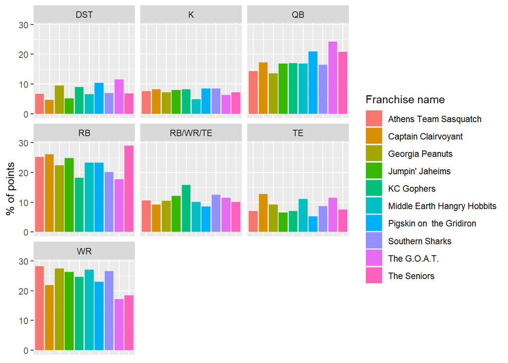

### Best pick-ups

There were 6 players added last week. Which was the **best pick-ups**?

| PCFL Team | Player | NFL Team | Position | Points |
| --- | --- | --- | --- | --- |
| Athens Team Sasquatch | Jason Sanders | MIA | K | 10.0 |
| Georgia Peanuts | Buccaneers D/ST | TBB | DST | 8.0 |
| The Seniors | Rams D/ST | LAR | DST | 6.0 |
| KC Gophers | Pat Freiermuth | PIT | TE | 4.4 |
| Georgia Peanuts | Odell Beckham Jr. | BAL | WR | 0.0 |
| Athens Team Sasquatch | Demario Douglas | NEP | WR | 0.0 |

Not much to see here late in the season.

### Best team performances

Here’s a list of the **top five scoring performances** so far this season.

| PCFL Team | Week | Score | Result |
| --- | --- | --- | --- |
| Athens Team Sasquatch | 8 | 180.02 | W |
| Middle Earth Hangry Hobbits | 2 | 167.18 | W |
| Athens Team Sasquatch | 13 | 159.28 | W |
| Jumpin’ Jaheims | 4 | 149.98 | W |
| Georgia Peanuts | 4 | 148.64 | W |

Robbie now owns 2 of the top 3 slots. Sigh.

## Looking ahead

### League standings

| PCFL Team | Division | Points scored | Avg points | Avg last 3 | W | L | Team points |
| --- | --- | --- | --- | --- | --- | --- | --- |
| Middle Earth Hangry Hobbits | Hot Dish | 1466.20 | 112.78 | 117.65 | 8 | 5 | 17 |
| Athens Team Sasquatch | Grits | 1493.88 | 114.91 | 130.85 | 8 | 5 | 16 |
| Georgia Peanuts | Hot Dish | 1477.38 | 113.64 | 120.89 | 8 | 5 | 16 |
| The Seniors | Hot Dish | 1449.17 | 111.47 | 120.04 | 7 | 6 | 15 |
| Pigskin on the Gridiron | Grits | 1392.24 | 107.10 | 108.25 | 8 | 5 | 15 |
| Southern Sharks | Hot Dish | 1351.61 | 103.97 | 94.85 | 5 | 8 | 12 |
| The G.O.A.T. | Grits | 1307.07 | 100.54 | 109.27 | 7 | 6 | 12 |
| Jumpin’ Jaheims | Grits | 1368.58 | 105.28 | 97.89 | 5 | 8 | 11 |
| KC Gophers | Hot Dish | 1305.08 | 100.39 | 126.33 | 4 | 9 | 9 |
| Captain Clairvoyant | Grits | 1231.75 | 94.75 | 112.72 | 5 | 8 | 7 |

### If the season ended today…

Playoffs would be Scott, Robbie, me, and Trav/Erin–the last spot is a tie breaker over Richard based on points scored. Sarah, Jacob, and Evan still have faint playoff hopes but it would be difficult. Crissy and Brian are eliminated.

### This week’s matchups

| Team 1 | Team 2 |
| --- | --- |
| Athens Team Sasquatch (Avg. last 3: 130.85) | KC Gophers (Avg. last 3: 126.33) |
| Captain Clairvoyant (Avg. last 3: 112.72) | Southern Sharks (Avg. last 3: 94.85) |
| Georgia Peanuts (Avg. last 3: 120.89) | The G.O.A.T. (Avg. last 3: 109.27) |
| Jumpin’ Jaheims (Avg. last 3: 97.89) | Middle Earth Hangry Hobbits (Avg. last 3: 117.65) |
| Pigskin on the Gridiron (Avg. last 3: 108.25) | The Seniors (Avg. last 3: 120.04) |

Evan, Jacob, and Richard all are facing teams ahead of them in the standings and need a victory.

Good luck, y’all!